# Lecture 2: Intro to Data Analytics

Let’s consider a new variable: the difference between desired weight (wtdesire) and current weight (weight).

Create this new variable by subtracting the two columns in the data frame and assigning them to a new object called wdiff.

```r
wdiff = cdc$wtdesire - cdc$weight
```

What type of data is wdiff? If an observation wdiff is 0, what does this mean about the person’s weight and desired weight. *If the variable wdiff is zero, then the individual’s weight is actually the desired one, so he is healthy.*

What if wdiff is positive or negative? *If it is positive, it means that the individual is under weighted and needs to gain more weight in order to be healthy. If the opposite happens (wdiff < 0), that means the individual is over weighted and needs to lose weight to be healthy.*

Describe the distribution of wdiff in terms of its center, shape, and spread, including any plots you use.

```r
summ_wdiff <- summary(wdiff)
summ_wdiff
```

```
##    Min. 1st Qu.  Median    Mean 3rd Qu.    Max.
## -300.00  -21.00  -10.00  -14.59    0.00  500.00
```

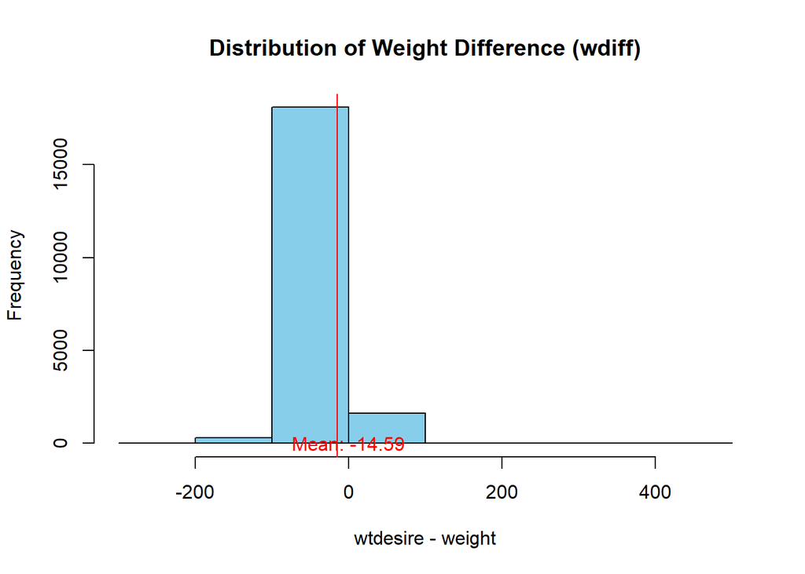

```r
hist(wdiff, breaks = 10, main="Distribution of Weight Difference (wdiff)",
     xlab = "wtdesire - weight", col = "skyblue")
abline(v = mean(wdiff), col = "red")
text(0, 0, paste("Mean:", round(mean(wdiff), 2)), col = "red")
```

*The distribution of the variable wdiff, according to the histogram, their values gather around the mean.*

What does this tell us about how people feel about their current weight? *The mean is negative (-14.59), it tells us that, on average, people in the sample have more weight than their desired weight, which means their over weighted, on average, by 14.59 lbs.*

Using mumerical summaries and a side-by-side box plot, determine if men tend to view their weight differently than women.

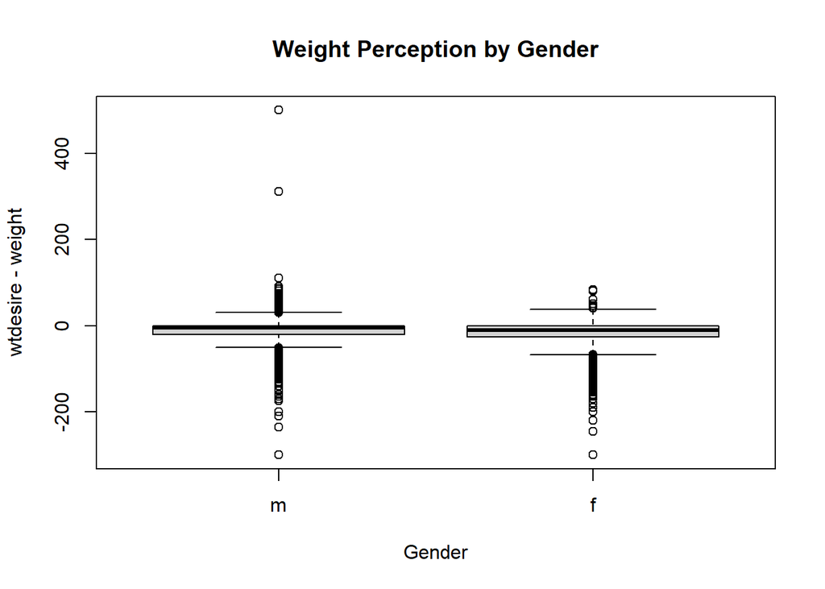

```r
boxplot(wdiff ~ gender, data = cdc,
        main = "Weight Perception by Gender", xlab = "Gender", ylab = "wtdesire - weight")
```

Now it’s time to get creative. Find the mean and standard deviation of weight and determine what proportion of the weights are within one standard deviation of the mean.

```r
mean_weight <- mean(cdc$weight)
sd_weight <- sd(cdc$weight)

#Proportion within one sd of the mean
prop1sd <-sum(abs(cdc$weight-mean_weight) <= sd_weight)/nrow(cdc)

cat("The mean of the variable weight is: ",mean_weight, "\n")
```

```
## The mean of the variable weight is:  169.683
```

```r
cat("The standard deviation of weight is: ",sd_weight, "\n")
```

```
## The standard deviation of weight is:  40.08097
```

```r
cat("The proportion of weights that re within one sd of the mean is: ",prop1sd)
```

```
## The proportion of weights that re within one sd of the mean is:  0.7076
```